# Regression Discontinuity Problem Set

Guo Zhan

```r
library(ggplot2)
library(dplyr)
library(miceadds)
library(ivreg)
library(knitr)
```

```r
psdata = read.csv("rd_problem_set.csv")
head(psdata)
```

```
##   female age college nhhld   inc2019 pab2019 emp2020
## 1      0  49       1     1 15554.620       0       0
## 2      0  40       0     1  6747.903    2498       0
## 3      0  18       1     1  4957.522    2498       1
## 4      1  34       0     1 23381.310       0       0
## 5      1  26       0     1  8167.408    2498       0
## 6      0  47       0     1 16063.780       0       1
```

```r
cat("Dimensions:", dim(psdata), "\n")
```

```
## Dimensions: 68834 7
```

# Question 1: How the Benefit Schedule Creates an RD Opportunity

**How this creates an RD opportunity:** The sharp income cutoff generates a discontinuous jump in cash benefits exactly at the FPL. Households on either side of this threshold are likely very similar in unobserved characteristics — labor market attachment, motivation, local conditions — because the exact dollar position of household income relative to the FPL is largely determined by many separate small decisions across the year and is not precisely controllable. We can therefore compare 2020 employment outcomes for households just *below* the FPL (who received benefits) against households just *above* (who did not), treating proximity to the cutoff as quasi-random assignment.

**Identifying assumptions and their intuitions:**

1. **No manipulation / Continuity of the running variable:** Households cannot precisely sort themselves just below the FPL to obtain benefits. If they could, we would see a suspicious pile-up of observations just below each threshold.
2. **Continuity of potential outcomes:** Among households near the threshold, the relationship between 2019 income and potential 2020 employment (absent the program) is smooth through the cutoff. A household earning $16,800 and one earning $17,000 in a two-person household are nearly identical in their underlying employment prospects; any sharp jump in actual 2020 employment at the FPL can therefore be attributed to the benefit, not to differences in household type.
3. **Sharp RD / LATE:** Because eligibility is fully determined by crossing the threshold, this is a sharp RD. The estimate identifies the Local Average Treatment Effect — the causal effect of the benefit for households right at the poverty limit.

# Question 2: Preliminaries

```r
# A. Federal Poverty Limit for each household
psdata$fpl = ifelse(psdata$nhhld == 1, 12490,
              ifelse(psdata$nhhld == 2, 16910,
              ifelse(psdata$nhhld == 3, 21330,
                     25750)))

cat("FPL summary by household size:\n")
```

```
## FPL summary by household size:
```

```r
print(tapply(psdata$fpl, psdata$nhhld, unique))
```

```
##     1     2     3     4     5     6
## 12490 16910 21330 25750 25750 25750
```

```r
# B. Running variable: income relative to household-specific FPL
psdata$runvar = psdata$inc2019 - psdata$fpl

# C. Binned running variable: round to nearest $100
psdata$runvarbin = round(psdata$runvar / 100) * 100

# D. Indicator D = 1 if income ABOVE the FPL (ineligible)
psdata$D = ifelse(psdata$runvar > 0, 1, 0)

# E. Indicator T = 1 if poverty assistance benefits are positive
psdata$T = ifelse(psdata$pab2019 > 0, 1, 0)

# F. Analysis sample: bandwidth +/- $5000
workdata = psdata[abs(psdata$runvar) <= 5000, ]

cat("\nFull sample size:", nrow(psdata), "\n")
```

```
##
## Full sample size: 68834
```

```r
cat("Analysis sample (BW +/-$5000):", nrow(workdata), "\n")
```

```
## Analysis sample (BW +/-$5000): 20868
```

```r
cat("Share with T=1 in analysis sample:", round(mean(workdata$T), 3), "\n")
```

```
## Share with T=1 in analysis sample: 0.566
```

```r
cat("Mean pab2019 in analysis sample:", round(mean(workdata$pab2019), 2), "\n")
```

```
## Mean pab2019 in analysis sample: 2220.04
```

# Question 3: Sharp RD First Stage — Regressions and Plots

```r
# Interaction term
workdata$Drunvar = workdata$D * workdata$runvar

# First stage 1
fs_T_clust = lm.cluster(T ~ runvar + D + Drunvar, cluster = "runvarbin", data = workdata)
print(summary(fs_T_clust))
```

```
## R^2= 1
##
##                  Estimate   Std. Error       t value     Pr(>|t|)
## (Intercept)  1.000000e+00 1.195922e-17  8.361752e+16 0.000000e+00
## runvar       1.700201e-19 8.456194e-21  2.010598e+01 6.541307e-90
## D           -1.000000e+00 6.571576e-16 -1.521705e+15 0.000000e+00
## Drunvar     -6.740902e-19 7.181774e-19 -9.386125e-01 3.479297e-01
##                  Estimate   Std. Error       t value     Pr(>|t|)
## (Intercept)  1.000000e+00 1.195922e-17  8.361752e+16 0.000000e+00
## runvar       1.700201e-19 8.456194e-21  2.010598e+01 6.541307e-90
## D           -1.000000e+00 6.571576e-16 -1.521705e+15 0.000000e+00
## Drunvar     -6.740902e-19 7.181774e-19 -9.386125e-01 3.479297e-01
```

```r
# First stage 2
fs_pab_clust = lm.cluster(pab2019 ~ runvar + D + Drunvar, cluster = "runvarbin", data = workdata)
print(summary(fs_pab_clust))
```

```
## R^2= 0.87409
##
##                  Estimate   Std. Error    t value     Pr(>|t|)
## (Intercept)  4.080736e+03 19.521842708  209.03438 0.000000e+00
## runvar       6.116361e-02  0.005723703   10.68602 1.183402e-26
## D           -4.080736e+03 19.521842708 -209.03438 0.000000e+00
## Drunvar     -6.116361e-02  0.005723703  -10.68602 1.183402e-26
##                  Estimate   Std. Error    t value     Pr(>|t|)
## (Intercept)  4.080736e+03 19.521842708  209.03438 0.000000e+00
## runvar       6.116361e-02  0.005723703   10.68602 1.183402e-26
## D           -4.080736e+03 19.521842708 -209.03438 0.000000e+00
## Drunvar     -6.116361e-02  0.005723703  -10.68602 1.183402e-26
```

```r
# Also run plain lm for coefficient extraction
fs_T_lm = lm(T ~ runvar + D + Drunvar, data = workdata)
fs_pab_lm = lm(pab2019 ~ runvar + D + Drunvar, data = workdata)
b_fs_T = coef(fs_T_lm)["D"]
b_fs_pab = coef(fs_pab_lm)["D"]

cat("\nCoefficient on D (T regression):", round(b_fs_T, 4), "\n")
```

```
##
## Coefficient on D (T regression): -1
```

```r
cat("Coefficient on D (pab2019 regression):", round(b_fs_pab, 2), "\n")
```

```
## Coefficient on D (pab2019 regression): -4080.74
```

**Interpretation:**

The coefficient on D in the first regression estimates the change in the probability of receiving benefits when income crosses the FPL threshold. Since D=1 means the household is **above** the FPL and ineligible, we expect a large negative coefficient close to −1, confirming a sharp drop in treatment status.

In the second regression, the coefficient on D estimates the drop in the dollar value of benefits at the threshold. This equals approximately the benefit amount (20% of the FPL) for the households at the margin.

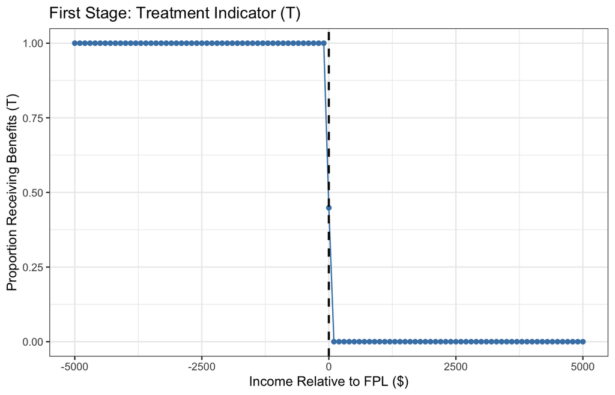

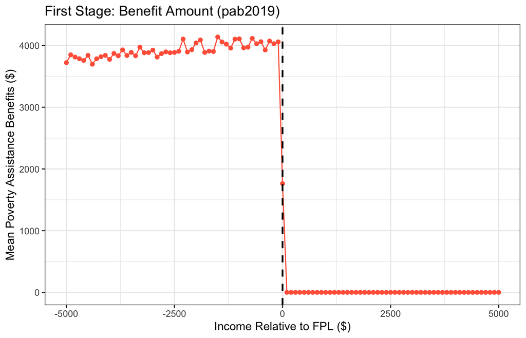

```r
# Bin means
bin_T = workdata %>%
  group_by(runvarbin) %>%
  summarise(mean_T = mean(T), .groups = "drop")
bin_pab = workdata %>%
  group_by(runvarbin) %>%
  summarise(mean_pab = mean(pab2019), .groups = "drop")

# Plot 1: T
ggplot(bin_T, aes(x = runvarbin, y = mean_T)) +
  geom_point(color = "steelblue", size = 1.5) +
  geom_line(color = "steelblue") +
  geom_vline(xintercept = 0, color = "black", linetype = "dashed", linewidth = 0.8) +
  scale_y_continuous(limits = c(0, 1)) +
  labs(title = "First Stage: Treatment Indicator (T)",
       x = "Income Relative to FPL ($)",
       y = "Proportion Receiving Benefits (T)") +
  theme_bw()

# Plot 2: pab2019
ggplot(bin_pab, aes(x = runvarbin, y = mean_pab)) +
  geom_point(color = "tomato", size = 1.5) +
  geom_line(color = "tomato") +
  geom_vline(xintercept = 0, color = "black", linetype = "dashed", linewidth = 0.8) +
  labs(title = "First Stage: Benefit Amount (pab2019)",
       x = "Income Relative to FPL ($)",
       y = "Mean Poverty Assistance Benefits ($)") +
  theme_bw()
```

**Are the graphs consistent with the regressions?** Yes. Both plots show a sharp, near-complete discontinuity at runvar=0. Households just below the threshold (left of the dashed line) universally receive the full statutory benefit, while those just above receive nothing. This pattern confirms the sharp RD structure and is consistent with the large negative coefficient on D in both regressions.

# Question 4: Reduced Form — Regressions and Plots

```r
# Reduced form
rf_emp_clust = lm.cluster(emp2020 ~ runvar + D + Drunvar, cluster = "runvarbin", data = workdata)
print(summary(rf_emp_clust))
```

```
## R^2= 0.00185
##
##                  Estimate   Std. Error    t value   Pr(>|t|)
## (Intercept)  4.796557e-01 1.066559e-02 44.9722609 0.00000000
## runvar      -1.785748e-06 3.401115e-06 -0.5250477 0.59955004
## D           -3.114844e-02 1.510072e-02 -2.0627122 0.03913998
## Drunvar     -1.112958e-06 5.076866e-06 -0.2192214 0.82647758
##                  Estimate   Std. Error    t value   Pr(>|t|)
## (Intercept)  4.796557e-01 1.066559e-02 44.9722609 0.00000000
## runvar      -1.785748e-06 3.401115e-06 -0.5250477 0.59955004
## D           -3.114844e-02 1.510072e-02 -2.0627122 0.03913998
## Drunvar     -1.112958e-06 5.076866e-06 -0.2192214 0.82647758
```

```r
# Plain lm for coefficient extraction
rf_emp_lm = lm(emp2020 ~ runvar + D + Drunvar, data = workdata)
b_rf = coef(rf_emp_lm)["D"]

cat("\nReduced form coefficient on D:", round(b_rf, 5), "\n")
```

```
##
## Reduced form coefficient on D: -0.03115
```

**Interpretation:** The coefficient on D estimates the discontinuous change in 2020 employment rates at the FPL threshold. A **negative** coefficient means that households just above the threshold — who received no benefits — have a **lower** probability of being employed in 2020 relative to nearly identical households just below the threshold who received benefits. This implies that the poverty assistance benefits had a **positive causal effect on employment**.

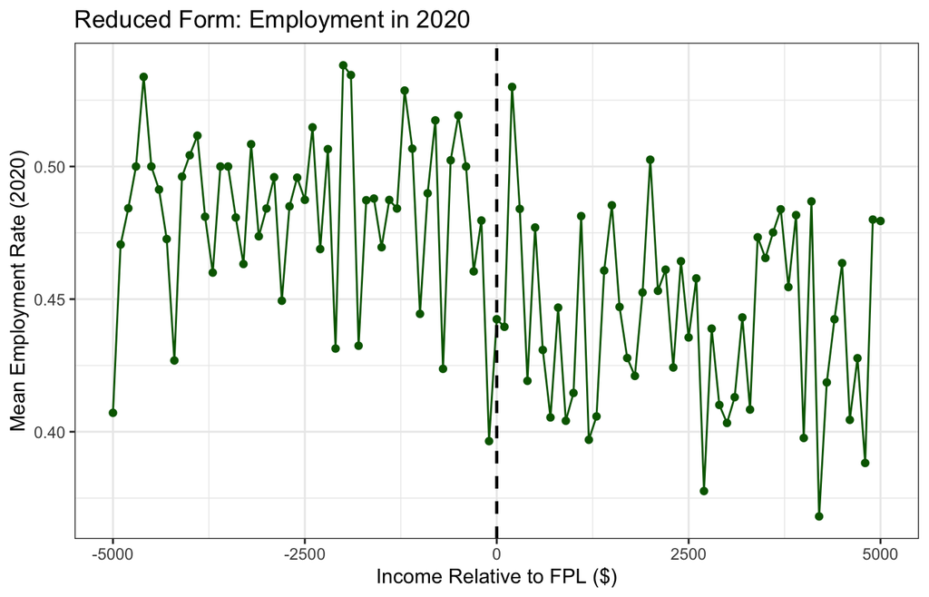

```r
bin_emp = workdata %>%
  group_by(runvarbin) %>%
  summarise(mean_emp = mean(emp2020), .groups = "drop")

ggplot(bin_emp, aes(x = runvarbin, y = mean_emp)) +
  geom_point(color = "darkgreen", size = 1.5) +
  geom_line(color = "darkgreen") +
  geom_vline(xintercept = 0, color = "black", linetype = "dashed", linewidth = 0.8) +
  labs(title = "Reduced Form: Employment in 2020",
       x = "Income Relative to FPL ($)",
       y = "Mean Employment Rate (2020)") +
  theme_bw()
```

**Interpretation in terms of program impacts:** The graph and regression together show that receiving poverty assistance benefits in 2019 led to higher employment in 2020. The cash transfer may have helped recipients cover job-search costs or provided a financial cushion that allowed them to pursue better job matches rather than accepting the first available opportunity.

## IV Estimate: Impact of $1,000 of Benefits on Employment

```r
# IV ratio: effect per $1 of benefits = RF / FS (using pab2019 as instrument)
b_iv_per_dollar = b_rf / b_fs_pab

cat("Reduced form coefficient on D (emp2020):", round(b_rf, 6), "\n")
```

```
## Reduced form coefficient on D (emp2020): -0.031148
```

```r
cat("First stage coefficient on D (pab2019):", round(b_fs_pab, 2), "\n")
```

```
## First stage coefficient on D (pab2019): -4080.74
```

```r
cat("IV estimate per $1 of benefits:", round(b_iv_per_dollar, 7), "\n")
```

```
## IV estimate per $1 of benefits: 7.6e-06
```

```r
cat("IV estimate per $1,000 of benefits:", round(1000 * b_iv_per_dollar, 4), "\n")
```

```
## IV estimate per $1,000 of benefits: 0.0076
```

**Interpretation:** The ratio $\hat{\beta}_{RF} / \hat{\beta}_{FS}$ scales the reduced-form employment effect by the size of the benefit discontinuity at the threshold, giving the effect on employment probability per dollar of benefits. Multiplying by 1,000 gives the effect of an additional **$1,000** of poverty assistance benefits on the probability of being employed in 2020.

# Question 5: Frequencies Plot

```r
# Aggregate counts per bin (one obs per bin)
bin_freq = workdata %>%
  group_by(runvarbin) %>%
  summarise(Nobs  = n(),
            D_bin = first(D),
            .groups = "drop")

# Cubic polynomial of binned running variable and interactions
bin_freq$rv = bin_freq$runvarbin
bin_freq$rv2 = bin_freq$rv^2
bin_freq$rv3 = bin_freq$rv^3
bin_freq$Drv = bin_freq$D_bin * bin_freq$rv
bin_freq$Drv2 = bin_freq$D_bin * bin_freq$rv2
bin_freq$Drv3 = bin_freq$D_bin * bin_freq$rv3

# Regression: Nobs on cubic polynomial + D
freq_reg = lm(Nobs ~ rv + rv2 + rv3 + D_bin + Drv + Drv2 + Drv3, data = bin_freq)
print(summary(freq_reg))
```

```
##
## Call:
## lm(formula = Nobs ~ rv + rv2 + rv3 + D_bin + Drv + Drv2 + Drv3,
##     data = bin_freq)
##
## Residuals:
##     Min      1Q  Median      3Q     Max
## -91.240  -8.319   2.821   9.879  53.168
##
## Coefficients:
##               Estimate Std. Error t value Pr(>|t|)
## (Intercept)  2.131e+02  1.047e+01  20.346   <2e-16 ***
## rv           8.355e-03  1.832e-02   0.456   0.6494
## rv2          1.271e-05  8.562e-06   1.485   0.1410
## rv3          2.063e-09  1.125e-09   1.834   0.0699 .
## D_bin       -1.377e+01  1.613e+01  -0.853   0.3956
## Drv         -1.986e-02  2.759e-02  -0.720   0.4735
## Drv2        -7.749e-06  1.268e-05  -0.611   0.5426
## Drv3        -3.087e-09  1.649e-09  -1.872   0.0644 .
## ---
## Signif. codes:  0 '***' 0.001 '**' 0.01 '*' 0.05 '.' 0.1 ' ' 1
##
## Residual standard error: 20.09 on 93 degrees of freedom
## Multiple R-squared:  0.7208, Adjusted R-squared:  0.6998
## F-statistic:  34.3 on 7 and 93 DF,  p-value: < 2.2e-16
```

```r
cat("\nCoefficient on D_bin:", round(coef(freq_reg)["D_bin"], 3),
    " | p-value:", round(summary(freq_reg)$coefficients["D_bin","Pr(>|t|)"], 4), "\n")
```

```
##
## Coefficient on D_bin: -13.767  | p-value: 0.3956
```

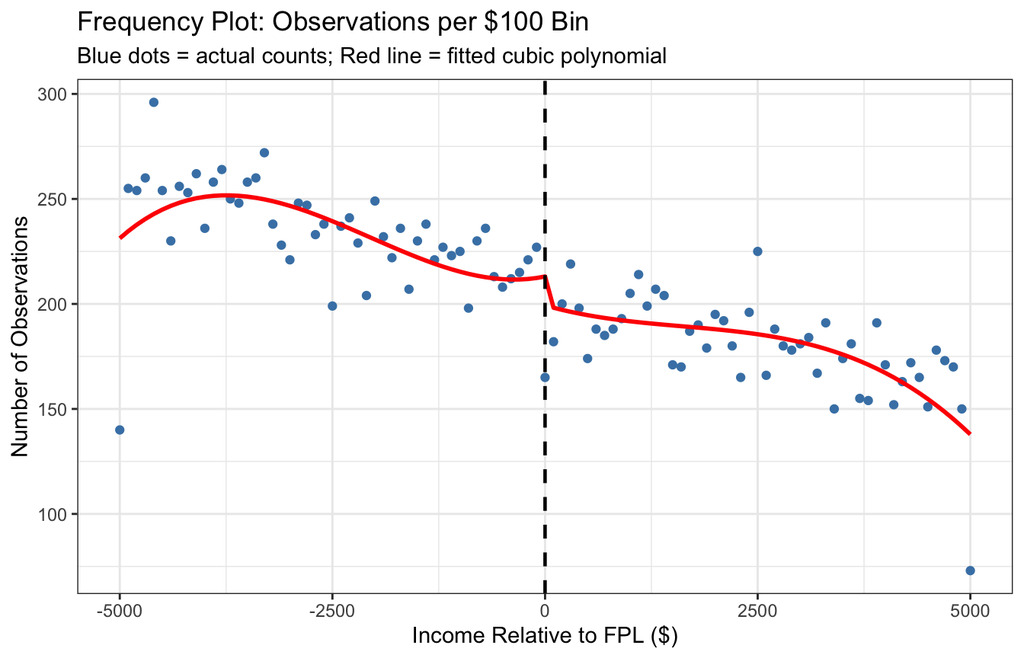

```r
bin_freq$pred_freq = predict(freq_reg)

# Plot
ggplot(bin_freq, aes(x = rv)) +
  geom_point(aes(y = Nobs), color = "steelblue", size = 1.5) +
  geom_line(aes(y = pred_freq), color = "red", linewidth = 1) +
  geom_vline(xintercept = 0, color = "black", linetype = "dashed", linewidth = 0.8) +
  labs(title = "Frequency Plot: Observations per $100 Bin",
       subtitle = "Blue dots = actual counts; Red line = fitted cubic polynomial",
       x = "Income Relative to FPL ($)",
       y = "Number of Observations") +
  theme_bw()
```

The coefficient on D is **not statistically significant**.

If households could manipulate their reported income to just qualify for benefits, we would expect a sharp spike in the number of observations just *below* zero (bunching below the threshold) and a corresponding trough just above it. But since the coefficient on D is **not statistically significant** and the plot shows a relatively smooth, continuous frequency distribution through the threshold, this provides evidence that households cannot (or do not) strategically manipulate their income to qualify — supporting the RD identifying assumption of no manipulation.

# Question 6: Covariate Predicted Employment

```r
# Create polynomial terms on the full dataset
psdata$age2 = psdata$age^2
psdata$age3 = psdata$age^3
psdata$inc2 = psdata$inc2019^2
psdata$inc3 = psdata$inc2019^3

# Regress emp2020 on all covariates
cov_reg = lm(emp2020 ~ age + age2 + age3 + female + college + factor(nhhld) + inc2019 + inc2 + inc3, data = psdata)

# Obtain fitted values
psdata$emp_hat = predict(cov_reg, newdata = psdata)

# Restrict to analysis bandwidth and add interaction
workdata_cov = psdata[abs(psdata$runvar) <= 5000, ]
workdata_cov$Drunvar = workdata_cov$D * workdata_cov$runvar

# RD regression with predicted employment as outcome
cov_rd_clust = lm.cluster(emp_hat ~ runvar + D + Drunvar,
                           cluster = "runvarbin", data = workdata_cov)
print(summary(cov_rd_clust))
```

```
## R^2= 0.03161
##
##                  Estimate   Std. Error      t value     Pr(>|t|)
## (Intercept)  4.640539e-01 2.548110e-04 1821.1689225 0.000000e+00
## runvar      -8.056968e-07 7.362692e-08  -10.9429643 7.181280e-28
## D            3.862395e-04 3.153963e-04    1.2246165 2.207198e-01
## Drunvar      2.725712e-08 1.003727e-07    0.2715592 7.859610e-01
##                  Estimate   Std. Error      t value     Pr(>|t|)
## (Intercept)  4.640539e-01 2.548110e-04 1821.1689225 0.000000e+00
## runvar      -8.056968e-07 7.362692e-08  -10.9429643 7.181280e-28
## D            3.862395e-04 3.153963e-04    1.2246165 2.207198e-01
## Drunvar      2.725712e-08 1.003727e-07    0.2715592 7.859610e-01
```

```r
cov_rd_lm = lm(emp_hat ~ runvar + D + Drunvar, data = workdata_cov)
cat("\nCoefficient on D:", round(coef(cov_rd_lm)["D"], 6),
    " | p-value:", round(summary(cov_rd_lm)$coefficients["D","Pr(>|t|)"], 4), "\n")
```

```
##
## Coefficient on D: 0.000386  | p-value: 0.2375
```

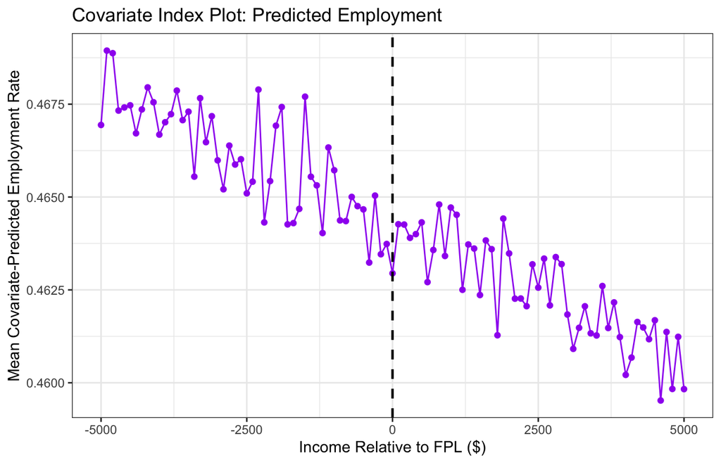

```r
# Covariate index plot
bin_cov = workdata_cov %>%
           group_by(runvarbin) %>%
           summarise(mean_emphat = mean(emp_hat), .groups = "drop")

ggplot(bin_cov, aes(x = runvarbin, y = mean_emphat)) +
  geom_point(color = "purple", size = 1.5) +
  geom_line(color = "purple") +
  geom_vline(xintercept = 0, color = "black", linetype = "dashed", linewidth = 0.8) +
  labs(title = "Covariate Index Plot: Predicted Employment",
       x = "Income Relative to FPL ($)",
       y = "Mean Covariate-Predicted Employment Rate") +
  theme_bw()
```

**How do these results compare to Q4?** In the covariate index test, the outcome is employment predicted solely from observable household characteristics (age, gender, education, household size, income). There is no discontinuity in the predicted employment at the threshold, so it means that observable household characteristics are balanced on both sides of the cutoff. Households just below and just above the FPL look the same in terms of observables.

**Relationship to RD identifying assumptions:** The RD design requires that households cannot sort themselves around the threshold based on unobserved characteristics. Since we showed that observed characteristics are smooth through the threshold (coefficient on D is **insignificant** in this regression), it is reassuring that unobservables are likely balanced too. This strengthens our confidence that the employment effect estimated in Q4 is genuinely causal, attributable to the benefits rather than pre-existing differences between households near the cutoff.

# Question 7: Sensitivity Analysis — Polynomial Specification

```r
# Additional polynomial terms for workdata_cov
workdata_cov$runvar2 = workdata_cov$runvar^2
workdata_cov$runvar3 = workdata_cov$runvar^3
workdata_cov$Drunvar2 = workdata_cov$D * workdata_cov$runvar2
workdata_cov$Drunvar3 = workdata_cov$D * workdata_cov$runvar3

# Linear specification
poly1 = lm(emp2020 ~ runvar + D + Drunvar, data = workdata_cov)

# Quadratic specification
poly2 = lm(emp2020 ~ runvar + runvar2 + D + Drunvar + Drunvar2, data = workdata_cov)

# Cubic specification
poly3 = lm(emp2020 ~ runvar + runvar2 + runvar3 + D + Drunvar + Drunvar2 + Drunvar3, data = workdata_cov)

# Summarize estimates
results_poly = data.frame(
  Specification = c("Linear", "Quadratic", "Cubic"),
  Coef_D = c(coef(poly1)["D"],
             coef(poly2)["D"],
             coef(poly3)["D"]),
  SE_D = c(sqrt(vcov(poly1)["D","D"]),
           sqrt(vcov(poly2)["D","D"]),
           sqrt(vcov(poly3)["D","D"])
  )
)
results_poly$t_stat = results_poly$Coef_D / results_poly$SE_D
results_poly$p_value = 2 * pt(-abs(results_poly$t_stat),
                               df = c(nrow(workdata_cov) - 4,
                                      nrow(workdata_cov) - 6,
                                      nrow(workdata_cov) - 8))
kable(results_poly,
      digits = 5,
      caption = "RD Estimates by Polynomial Specification (outcome: emp2020)")
```

RD Estimates by Polynomial Specification (outcome: emp2020)

| Specification | Coef_D | SE_D | t_stat | p_value |
| --- | --- | --- | --- | --- |
| Linear | -0.03115 | 0.01395 | -2.23354 | 0.02552 |
| Quadratic | -0.01158 | 0.02102 | -0.55098 | 0.58166 |
| Cubic | 0.01201 | 0.02821 | 0.42556 | 0.67043 |

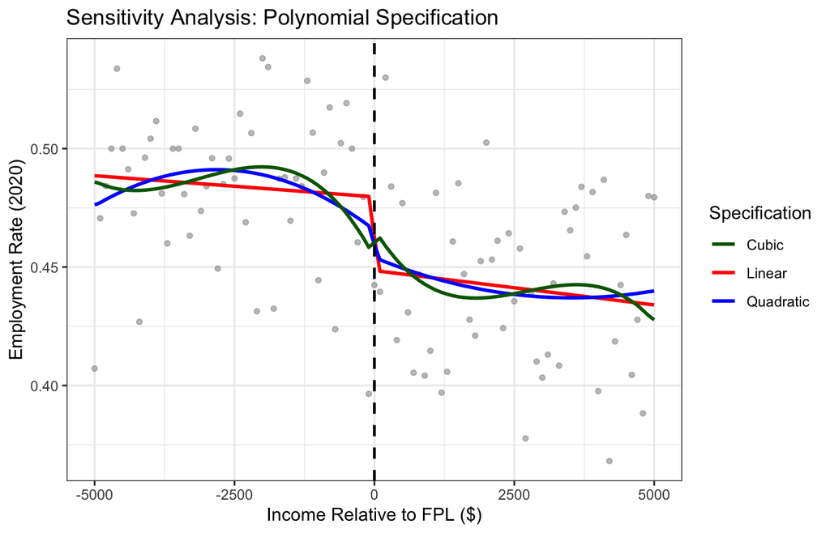

```r
# Fitted values per bin
workdata_cov$pred1 = predict(poly1)
workdata_cov$pred2 = predict(poly2)
workdata_cov$pred3 = predict(poly3)

bin_poly = workdata_cov %>%
  group_by(runvarbin) %>%
  summarise(mean_emp = mean(emp2020),
            mean_p1 = mean(pred1),
            mean_p2 = mean(pred2),
            mean_p3 = mean(pred3),
            .groups = "drop")

ggplot(bin_poly, aes(x = runvarbin)) +
  geom_point(aes(y = mean_emp), color = "gray60", size = 1.2, alpha = 0.6) +
  geom_line(aes(y = mean_p1, color = "Linear"),    linewidth = 1) +
  geom_line(aes(y = mean_p2, color = "Quadratic"), linewidth = 1) +
  geom_line(aes(y = mean_p3, color = "Cubic"),     linewidth = 1) +
  geom_vline(xintercept = 0, color = "black", linetype = "dashed", linewidth = 0.8) +
  scale_color_manual(values = c("Linear"="red","Quadratic"="blue","Cubic"="darkgreen")) +
  labs(title = "Sensitivity Analysis: Polynomial Specification",
       x = "Income Relative to FPL ($)",
       y = "Employment Rate (2020)",
       color = "Specification") +
  theme_bw()
```

# Question 8: Sensitivity Analysis — Bandwidth

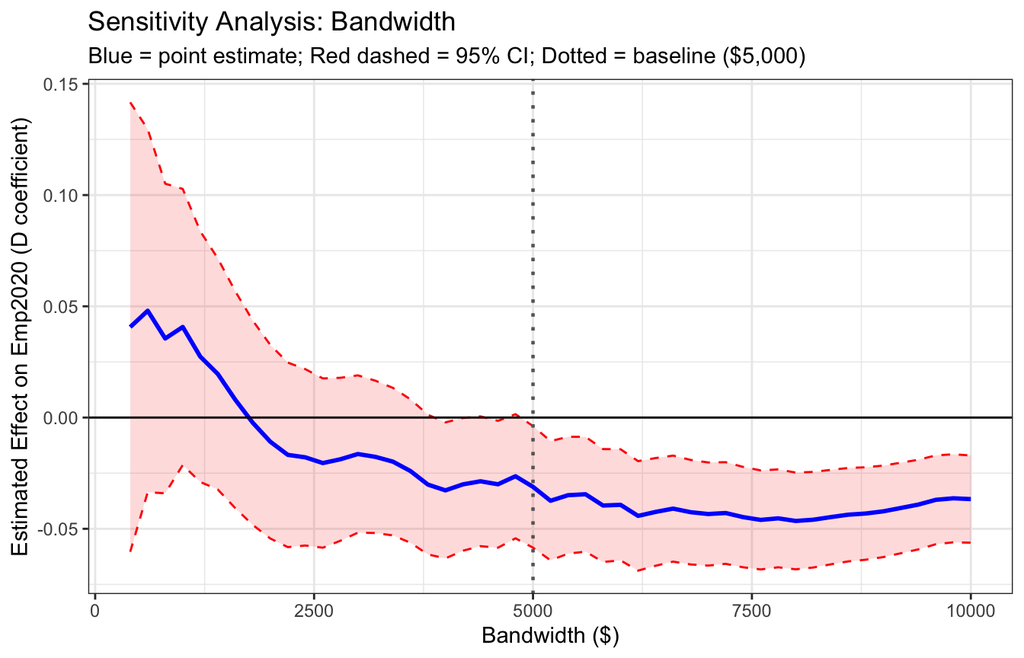

```r
# Vary bandwidth from +/-$400 to +/-$10,000 in steps of $200
bwidths = seq(400, 10000, by = 200)
CoefMatrix = matrix(NA, length(bwidths), 5)

for (ii in seq_along(bwidths)) {
  bw = bwidths[ii]
  bw_dat = psdata[abs(psdata$runvar) <= bw, ]

  if (nrow(bw_dat) < 20) next

  bw_dat$Drunvar = bw_dat$D * bw_dat$runvar
  bw_reg = lm(emp2020 ~ runvar + D + Drunvar, data = bw_dat)

  CoefMatrix[ii, 1] = bw
  CoefMatrix[ii, 2] = coef(bw_reg)["D"]
  CoefMatrix[ii, 3] = sqrt(vcov(bw_reg)["D","D"])
  CoefMatrix[ii, 4] = CoefMatrix[ii, 2] - 1.96 * CoefMatrix[ii, 3]
  CoefMatrix[ii, 5] = CoefMatrix[ii, 2] + 1.96 * CoefMatrix[ii, 3]
}

bw_df = as.data.frame(CoefMatrix[complete.cases(CoefMatrix), ])
colnames(bw_df) = c("bandwidth","estimate","se","ci_lo","ci_hi")

ggplot(bw_df, aes(x = bandwidth)) +
  geom_ribbon(aes(ymin = ci_lo, ymax = ci_hi), fill = "red", alpha = 0.15) +
  geom_line(aes(y = estimate), color = "blue", linewidth = 1) +
  geom_line(aes(y = ci_lo), color = "red", linetype = "dashed") +
  geom_line(aes(y = ci_hi), color = "red", linetype = "dashed") +
  geom_hline(yintercept = 0, color = "black") +
  geom_vline(xintercept = 5000, color = "gray40", linetype = "dotted", linewidth = 0.8) +
  labs(title = "Sensitivity Analysis: Bandwidth",
       subtitle = "Blue = point estimate; Red dashed = 95% CI; Dotted = baseline ($5,000)",
       x = "Bandwidth ($)",
       y = "Estimated Effect on Emp2020 (D coefficient)") +
  theme_bw()
```

```r
# Min bandwidth with statistical significance (CI excludes 0)
sig_bws = bw_df[sign(bw_df$ci_lo) == sign(bw_df$ci_hi), ]
cat("Minimum bandwidth with statistical significance: $",
    min(sig_bws$bandwidth, na.rm = TRUE), "\n")
```

```
## Minimum bandwidth with statistical significance: $ 4000
```

```r
cat("Estimate at baseline BW ($5000):",
    round(bw_df$estimate[bw_df$bandwidth == 5000], 5), "\n")
```

```
## Estimate at baseline BW ($5000): -0.03115
```

# Question 9: Sensitivity Analysis — Permutation Test

```r
set.seed(42)
reps = 500
perm_coefs = numeric(reps)

# FPL lookup by randomly drawn household size
fpl_lookup = c("1" = 12490, "2" = 16910, "3" = 21330, "4" = 25750)

for (ii in 1:reps) {
  # Randomly assign household size (1-4) and corresponding FPL to each household
  psdata$rand_nhhld = sample(1:4, nrow(psdata), replace = TRUE)
  psdata$rand_fpl = fpl_lookup[as.character(psdata$rand_nhhld)]

  # Permuted running variable and treatment indicator
  psdata$p_runvar = psdata$inc2019 - psdata$rand_fpl
  psdata$p_D = as.integer(psdata$p_runvar > 0)

  # Restrict to +/-$5000 bandwidth around permuted threshold
  p_dat = psdata[abs(psdata$p_runvar) <= 5000, ]

  if (nrow(p_dat) < 20) {
    perm_coefs[ii] = NA
    next
  }

  p_dat$pDrunvar = p_dat$p_D * p_dat$p_runvar
  p_reg = lm(emp2020 ~ p_runvar + p_D + pDrunvar, data = p_dat)
  perm_coefs[ii] = coef(p_reg)["p_D"]
}

perm_coefs = perm_coefs[!is.na(perm_coefs)]

# True estimate from the baseline linear RD (Q4)
true_est = coef(poly1)["D"]

cat("True RD estimate (D coefficient):", round(true_est, 5), "\n")
```

```
## True RD estimate (D coefficient): -0.03115
```

```r
cat("Mean permutation estimate:", round(mean(perm_coefs), 5), "\n")
```

```
## Mean permutation estimate: -0.00255
```

```r
cat("SD of permutation estimates:", round(sd(perm_coefs), 5), "\n")
```

```
## SD of permutation estimates: 0.01425
```

```r
perm_pval = mean(abs(perm_coefs) >= abs(true_est))
cat("Empirical p-value (fraction |perm| >= |true|):", round(perm_pval, 3), "\n")
```

```
## Empirical p-value (fraction |perm| >= |true|): 0.022
```

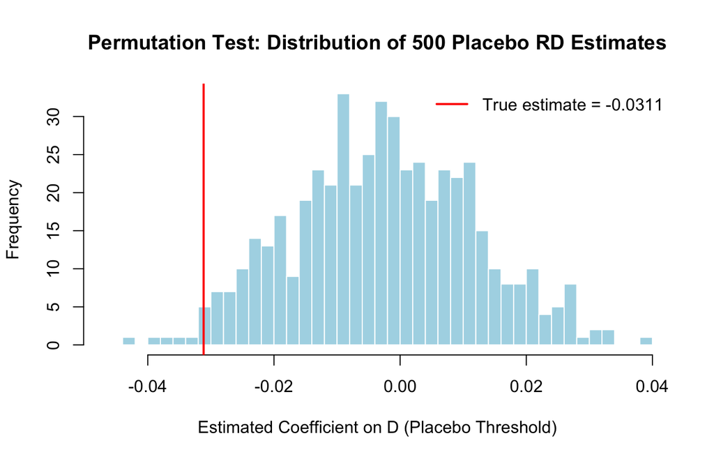

```r
# Histogram
hist(perm_coefs, breaks = 30,
     main = "Permutation Test: Distribution of 500 Placebo RD Estimates",
     xlab = "Estimated Coefficient on D (Placebo Threshold)",
     col = "lightblue", border = "white",
     xlim = range(c(perm_coefs, true_est * 1.5)))
abline(v = true_est, col = "red", lwd = 2)
legend("topright",
       legend = paste0("True estimate = ", round(true_est, 4)),
       col = "red", lwd = 2, bty = "n")
```

**Interpretation:** The permutation test addresses the concern that the estimated effect in Q4 might be spuriously driven by some structural feature of incomes near the FPL values (e.g., round-number effects in wage-setting or income reporting near certain income thresholds), rather than by the program itself.

By randomly reassigning household sizes — and thus FPL thresholds — to each observation, we create 500 placebo cutpoints unrelated to actual program eligibility. As shown in the output above, the distribution of these 500 placebo estimates is centered near zero, confirming that there is nothing structurally unusual about the income-employment relationship at arbitrary dollar thresholds.